# ExtraaLearn Project

## Context

The EdTech industry has been surging in the past decade immensely, and according to a forecast, the Online Education market would be worth $286.62bn by 2023 with a compound annual growth rate (CAGR) of 10.26% from 2018 to 2023. The modern era of online education has enforced a lot in its growth and expansion beyond any limit. Due to having many dominant features like ease of information sharing, personalized learning experience, transparency of assessment, etc, it is now preferable to traditional education.

In the present scenario due to the Covid-19, the online education sector has witnessed rapid growth and is attracting a lot of new customers. Due to this rapid growth, many new companies have emerged in this industry. With the availability and ease of use of digital marketing resources, companies can reach out to a wider audience with their offerings. The customers who show interest in these offerings are termed as leads. There are various sources of obtaining leads for Edtech companies, like

- The customer interacts with the marketing front on social media or other online platforms.
- The customer browses the website/app and downloads the brochure
- The customer connects through emails for more information.

The company then nurtures these leads and tries to convert them to paid customers. For this, the representative from the organization connects with the lead on call or through email to share further details.

## Objective

ExtraaLearn is an initial stage startup that offers programs on cutting-edge technologies to students and professionals to help them upskill/reskill. With a large number of leads being generated on a regular basis, one of the issues faced by ExtraaLearn is to identify which of the leads are more likely to convert so that they can allocate resources accordingly. You, as a data scientist at ExtraaLearn, have been provided the leads data to:

- Analyze and build an ML model to help identify which leads are more likely to convert to paid customers,
- Find the factors driving the lead conversion process
- Create a profile of the leads which are likely to convert

## Data Description

The data contains the different attributes of leads and their interaction details with ExtraaLearn. The detailed data dictionary is given below.

**Data Dictionary**

- ID: ID of the lead
- age: Age of the lead
- current_occupation: Current occupation of the lead. Values include 'Professional','Unemployed',and 'Student'
- first_interaction: How did the lead first interacted with ExtraaLearn. Values include 'Website', 'Mobile App'
- profile_completed: What percentage of profile has been filled by the lead on the website/mobile app. Values include Low - (0-50%), Medium - (50-75%), High (75-100%)
- website_visits: How many times has a lead visited the website
- time_spent_on_website: Total time spent on the website
- page_views_per_visit: Average number of pages on the website viewed during the visits.
- last_activity: Last interaction between the lead and ExtraaLearn.
  - Email Activity: Seeking for details about program through email, Representative shared information with lead like brochure of program , etc
  - Phone Activity: Had a Phone Conversation with representative, Had conversation over SMS with representative, etc
  - Website Activity: Interacted on live chat with representative, Updated profile on website, etc
- print_media_type1: Flag indicating whether the lead had seen the ad of ExtraaLearn in the Newspaper.
- print_media_type2: Flag indicating whether the lead had seen the ad of ExtraaLearn in the Magazine.
- digital_media: Flag indicating whether the lead had seen the ad of ExtraaLearn on the digital platforms.
- educational_channels: Flag indicating whether the lead had heard about ExtraaLearn in the education channels like online forums, discussion threads, educational websites, etc.
- referral: Flag indicating whether the lead had heard about ExtraaLearn through reference.
- status: Flag indicating whether the lead was converted to a paid customer or not.

## Importing necessary libraries and data

```python
%%html
<script>
    require( ["base/js/namespace", "jquery"], function(jupyter, $) {
        $(jupyter.events).on("kernel_ready.Kernel", function () {
            console.log("Auto-running all cells-below...");
            jupyter.actions.call('jupyter-notebook:run-all-cells-below');
            jupyter.actions.call('jupyter-notebook:save-notebook');
        });
    } );
</script>
```

```python
import pandas as pd

import numpy as np

import matplotlib.pyplot as plt

import seaborn as sns
import math as math

# To scale the data using z-score
from sklearn.preprocessing import StandardScaler

from sklearn.model_selection import train_test_split

# Algorithms to use
from sklearn import tree

from sklearn.tree import DecisionTreeClassifier, plot_tree

from sklearn.ensemble import RandomForestClassifier

# Metrics to evaluate the model
from sklearn import metrics

from sklearn.metrics import confusion_matrix, classification_report,recall_score,precision_score, accuracy_score

# For tuning the model
from sklearn.model_selection import GridSearchCV

# To ignore warnings
import warnings
warnings.filterwarnings("ignore")
```

```python
from google.colab import drive
drive.mount('/content/drive')
```

## Data Overview

- Observations
- Sanity checks

```python
data = pd.read_csv('/content/drive/MyDrive/ExtraaLearn.csv')
```

```python
data.head()
```

|  | ID | age | current_occupation | first_interaction | profile_completed | website_visits | time_spent_on_website | page_views_per_visit | last_activity | print_media_type1 | print_media_type2 | digital_media | educational_channels | referral | status |
| --- | --- | --- | --- | --- | --- | --- | --- | --- | --- | --- | --- | --- | --- | --- | --- |
| 0 | EXT001 | 57 | Unemployed | Website | High | 7 | 1639 | 1.861 | Website Activity | Yes | No | Yes | No | No | 1 |
| 1 | EXT002 | 56 | Professional | Mobile App | Medium | 2 | 83 | 0.320 | Website Activity | No | No | No | Yes | No | 0 |
| 2 | EXT003 | 52 | Professional | Website | Medium | 3 | 330 | 0.074 | Website Activity | No | No | Yes | No | No | 0 |
| 3 | EXT004 | 53 | Unemployed | Website | High | 4 | 464 | 2.057 | Website Activity | No | No | No | No | No | 1 |
| 4 | EXT005 | 23 | Student | Website | High | 4 | 600 | 16.914 | Email Activity | No | No | No | No | No | 0 |

## Exploratory Data Analysis (EDA)

- EDA is an important part of any project involving data.
- It is important to investigate and understand the data better before building a model with it.
- A few questions have been mentioned below which will help you approach the analysis in the right manner and generate insights from the data.
- A thorough analysis of the data, in addition to the questions mentioned below, should be done.

```python
data.info()
```

```
<class 'pandas.core.frame.DataFrame'>
RangeIndex: 4612 entries, 0 to 4611
Data columns (total 15 columns):
 #   Column                 Non-Null Count  Dtype
---  ------                 --------------  -----
 0   ID                     4612 non-null   object
 1   age                    4612 non-null   int64
 2   current_occupation     4612 non-null   object
 3   first_interaction      4612 non-null   object
 4   profile_completed      4612 non-null   object
 5   website_visits         4612 non-null   int64
 6   time_spent_on_website  4612 non-null   int64
 7   page_views_per_visit   4612 non-null   float64
 8   last_activity          4612 non-null   object
 9   print_media_type1      4612 non-null   object
 10  print_media_type2      4612 non-null   object
 11  digital_media          4612 non-null   object
 12  educational_channels   4612 non-null   object
 13  referral               4612 non-null   object
 14  status                 4612 non-null   int64
dtypes: float64(1), int64(4), object(10)
memory usage: 540.6+ KB
```

```python
data.shape
```

```
(4612, 15)
```

# Observations:

- There are total 4612 rows and 15 features.
- No record contains any null value so there is no missing value in data.
- There are 5 numeric columns and 10 objects.

```python
data.nunique()
```

|  | 0 |
| --- | --- |
| ID | 4612 |
| age | 46 |
| current_occupation | 3 |
| first_interaction | 2 |
| profile_completed | 3 |
| website_visits | 27 |
| time_spent_on_website | 1623 |
| page_views_per_visit | 2414 |
| last_activity | 3 |
| print_media_type1 | 2 |
| print_media_type2 | 2 |
| digital_media | 2 |
| educational_channels | 2 |
| referral | 2 |
| status | 2 |

**dtype:** int64

# Observation

- The Customer ID feature is not going to add any value to the data so this will be dropped.

```python
data = data.drop('ID' , axis = 1)

# Identify columns with all unique values

#columns_to_drop = []
#for col in data.columns:
 #   if data[col].nunique() == len(data):
  #      columns_to_drop.append(col)
#
# Drop the identified columns
#df_cleaned = data.drop(columns=columns_to_drop)
```

```python
data.head(1)
```

|  | age | current_occupation | first_interaction | profile_completed | website_visits | time_spent_on_website | page_views_per_visit | last_activity | print_media_type1 | print_media_type2 | digital_media | educational_channels | referral | status |
| --- | --- | --- | --- | --- | --- | --- | --- | --- | --- | --- | --- | --- | --- | --- |
| 0 | 57 | Unemployed | Website | High | 7 | 1639 | 1.861 | Website Activity | Yes | No | Yes | No | No | 1 |

```python
data.nunique()
```

|  | 0 |
| --- | --- |
| age | 46 |
| current_occupation | 3 |
| first_interaction | 2 |
| profile_completed | 3 |
| website_visits | 27 |
| time_spent_on_website | 1623 |
| page_views_per_visit | 2414 |
| last_activity | 3 |
| print_media_type1 | 2 |
| print_media_type2 | 2 |
| digital_media | 2 |
| educational_channels | 2 |
| referral | 2 |
| status | 2 |

**dtype:** int64

```python
data.shape
```

```
(4612, 14)
```

```python
data['first_interaction'].unique()
```

```
array(['Website', 'Mobile App'], dtype=object)
```

**Questions**

1. Leads will have different expectations from the outcome of the course and the current occupation may play a key role in getting them to participate in the program. Find out how current occupation affects lead status.
2. The company's first impression on the customer must have an impact. Do the first channels of interaction have an impact on the lead status?
3. The company uses multiple modes to interact with prospects. Which way of interaction works best?
4. The company gets leads from various channels such as print media, digital media, referrals, etc. Which of these channels have the highest lead conversion rate?
5. People browsing the website or mobile application are generally required to create a profile by sharing their personal data before they can access additional information.Does having more details about a prospect increase the chances of conversion?

```python
data.head(1)
```

|  | age | current_occupation | first_interaction | profile_completed | website_visits | time_spent_on_website | page_views_per_visit | last_activity | print_media_type1 | print_media_type2 | digital_media | educational_channels | referral | status |
| --- | --- | --- | --- | --- | --- | --- | --- | --- | --- | --- | --- | --- | --- | --- |
| 0 | 57 | Unemployed | Website | High | 7 | 1639 | 1.861 | Website Activity | Yes | No | Yes | No | No | 1 |

```python
data.describe(include = 'all').T
```

|  | count | unique | top | freq | mean | std | min | 25% | 50% | 75% | max |
| --- | --- | --- | --- | --- | --- | --- | --- | --- | --- | --- | --- |
| age | 4612.0 | NaN | NaN | NaN | 46.201214 | 13.161454 | 18.0 | 36.0 | 51.0 | 57.0 | 63.0 |
| current_occupation | 4612 | 3 | Professional | 2616 | NaN | NaN | NaN | NaN | NaN | NaN | NaN |
| first_interaction | 4612 | 2 | Website | 2542 | NaN | NaN | NaN | NaN | NaN | NaN | NaN |
| profile_completed | 4612 | 3 | High | 2264 | NaN | NaN | NaN | NaN | NaN | NaN | NaN |
| website_visits | 4612.0 | NaN | NaN | NaN | 3.566782 | 2.829134 | 0.0 | 2.0 | 3.0 | 5.0 | 30.0 |
| time_spent_on_website | 4612.0 | NaN | NaN | NaN | 724.011275 | 743.828683 | 0.0 | 148.75 | 376.0 | 1336.75 | 2537.0 |
| page_views_per_visit | 4612.0 | NaN | NaN | NaN | 3.026126 | 1.968125 | 0.0 | 2.07775 | 2.792 | 3.75625 | 18.434 |
| last_activity | 4612 | 3 | Email Activity | 2278 | NaN | NaN | NaN | NaN | NaN | NaN | NaN |
| print_media_type1 | 4612 | 2 | No | 4115 | NaN | NaN | NaN | NaN | NaN | NaN | NaN |
| print_media_type2 | 4612 | 2 | No | 4379 | NaN | NaN | NaN | NaN | NaN | NaN | NaN |
| digital_media | 4612 | 2 | No | 4085 | NaN | NaN | NaN | NaN | NaN | NaN | NaN |
| educational_channels | 4612 | 2 | No | 3907 | NaN | NaN | NaN | NaN | NaN | NaN | NaN |
| referral | 4612 | 2 | No | 4519 | NaN | NaN | NaN | NaN | NaN | NaN | NaN |
| status | 4612.0 | NaN | NaN | NaN | 0.298569 | 0.45768 | 0.0 | 0.0 | 0.0 | 1.0 | 1.0 |

```python
unique_info = {}
coltoanalyze =['current_occupation','first_interaction','profile_completed','digital_media','educational_channels']
for col in data[coltoanalyze]:
    num_unique = data[col].value_counts()
    unique_values = data[col].unique().tolist() # Convert to list for better readability
    unique_info[col] = {
        'count': num_unique,
        'values': unique_values
    }

# Print the results
for col, info in unique_info.items():
    print(f"Column: {col}")
    print(f"  Number of unique values: {info['count']}")
    print(f"  Unique values: {info['values']}")
    print("-" * 30)
```

```
Column: current_occupation
  Number of unique values: current_occupation
Professional    2616
Unemployed      1441
Student          555
Name: count, dtype: int64
  Unique values: ['Unemployed', 'Professional', 'Student']
------------------------------
Column: first_interaction
  Number of unique values: first_interaction
Website       2542
Mobile App    2070
Name: count, dtype: int64
  Unique values: ['Website', 'Mobile App']
------------------------------
Column: profile_completed
  Number of unique values: profile_completed
High      2264
Medium    2241
Low        107
Name: count, dtype: int64
  Unique values: ['High', 'Medium', 'Low']
------------------------------
Column: digital_media
  Number of unique values: digital_media
No     4085
Yes     527
Name: count, dtype: int64
  Unique values: ['Yes', 'No']
------------------------------
Column: educational_channels
  Number of unique values: educational_channels
No     3907
Yes     705
Name: count, dtype: int64
  Unique values: ['No', 'Yes']
------------------------------
```

```python
data.describe().T
```

|  | count | mean | std | min | 25% | 50% | 75% | max |
| --- | --- | --- | --- | --- | --- | --- | --- | --- |
| age | 4612.0 | 46.201214 | 13.161454 | 18.0 | 36.00000 | 51.000 | 57.00000 | 63.000 |
| website_visits | 4612.0 | 3.566782 | 2.829134 | 0.0 | 2.00000 | 3.000 | 5.00000 | 30.000 |
| time_spent_on_website | 4612.0 | 724.011275 | 743.828683 | 0.0 | 148.75000 | 376.000 | 1336.75000 | 2537.000 |
| page_views_per_visit | 4612.0 | 3.026126 | 1.968125 | 0.0 | 2.07775 | 2.792 | 3.75625 | 18.434 |
| status | 4612.0 | 0.298569 | 0.457680 | 0.0 | 0.00000 | 0.000 | 1.00000 | 1.000 |

# Observations:

- There is a right skew on the distribution of website visits, with only 25% of visitors having visited more than five times, however the maximum number of visits is 30. Such elevated skewness suggests outliers.
- There is a right skew on time spent on the_website, with again the likelihood of outliers.
- There is a right skew as well on page views per visit. Again, with the same implication regarding outliers.
- All numerical variables have elevated variance, which also warrants further analysis.
- Approximately 30% of all leads have converted to paying customers based on the status.
- Several variables have an unexpected minimum value of zero, including website_visits, time_spent_on_website and page_views_per_visit. This could affect the mean and the skew of the distributions.

```python
data[data['time_spent_on_website']==0].head()
```

|  | age | current_occupation | first_interaction | profile_completed | website_visits | time_spent_on_website | page_views_per_visit | last_activity | print_media_type1 | print_media_type2 | digital_media | educational_channels | referral | status |
| --- | --- | --- | --- | --- | --- | --- | --- | --- | --- | --- | --- | --- | --- | --- |
| 33 | 56 | Professional | Mobile App | Medium | 0 | 0 | 0.0 | Phone Activity | No | No | No | No | No | 0 |
| 37 | 59 | Professional | Website | High | 0 | 0 | 0.0 | Email Activity | No | No | No | No | No | 1 |
| 54 | 28 | Professional | Mobile App | High | 0 | 0 | 0.0 | Email Activity | No | No | No | Yes | No | 0 |
| 94 | 49 | Unemployed | Website | High | 0 | 0 | 0.0 | Email Activity | Yes | No | No | No | No | 1 |
| 127 | 54 | Professional | Mobile App | High | 0 | 0 | 0.0 | Phone Activity | No | No | No | No | No | 0 |

```python
data[data['time_spent_on_website']==0]['last_activity'].value_counts()
```

| last_activity | count |
| --- | --- |
| Email Activity | 119 |
| Phone Activity | 55 |

**dtype:** int64

```python
data[data['time_spent_on_website']==0]['status'].value_counts()
```

| status | count |
| --- | --- |
| 0 | 142 |
| 1 | 32 |

**dtype:** int64

**Observations**:

These leads, with no time spent on the website, are reported as having had a last activity via phone or email, and some of them have converted and have had their profile completed, presumably through interview.

**Visualization:**:

**Univariate analysis : Numeric features**

```python
#num_cols = ['age', 'website_visit', 'time_spent_on_website','page_views_per_visit', 'status']
#cat_cols = ['current_occupation','first_interaction','profile_completed','last_activity','print_media_type1','print_media_type2','digital_media','educational_channels','referral']
numeric_features = data.select_dtypes(include=['number']).columns
cat_features = data.select_dtypes(include=['object']).columns
```

```
age
```

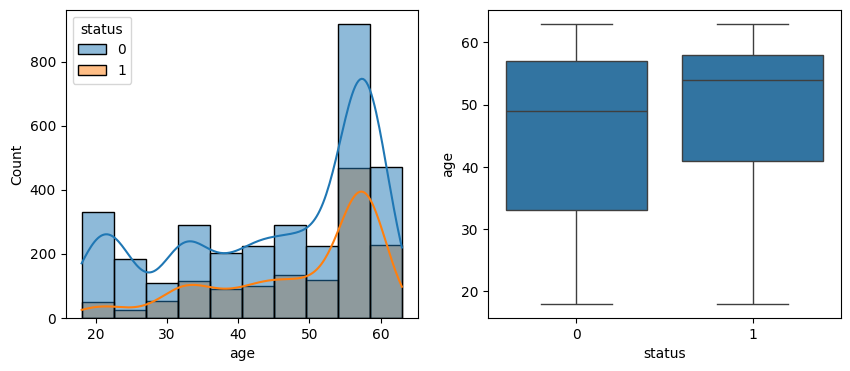

```
website_visits
```

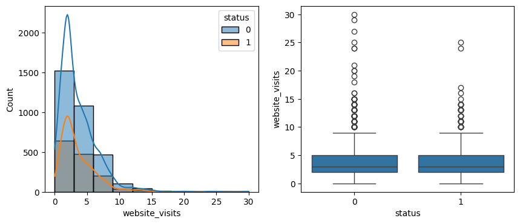

```
time_spent_on_website
```

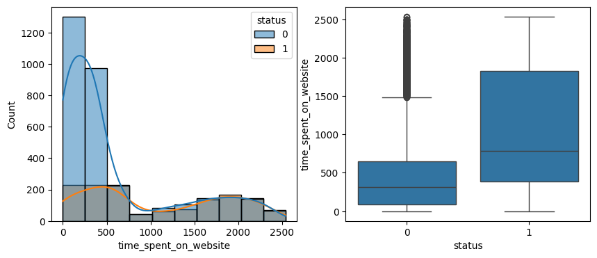

```
page_views_per_visit
```

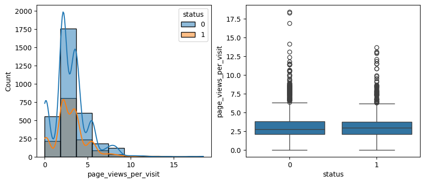

```
status
```

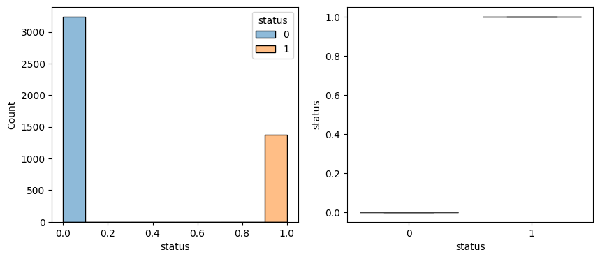

```python
for col in ['age', 'website_visits', 'time_spent_on_website','page_views_per_visit', 'status']:
    print(col)

    plt.figure(figsize = (10, 4))

    # Plot histogram as left subplot, with kde and hue by status
    plt.subplot(1, 2, 1)

    sns.histplot(data = data, x=col, bins = 10, hue=data['status'], kde=True)

    # Plot boxplot as right subplot, with hue by status
    plt.subplot(1, 2, 2)

    sns.boxplot(data, y=col, x='status')

    plt.show()
```

**Observations**:

```python
categorical_vars = list(data.select_dtypes(include=['object', 'category']).columns)
for per in categorical_vars:
    p = data[per].value_counts(normalize=True)*100
    print(p)
```

```
current_occupation
Professional    56.721596
Unemployed      31.244579
Student         12.033825
Name: proportion, dtype: float64
first_interaction
Website       55.117086
Mobile App    44.882914
Name: proportion, dtype: float64
profile_completed
High      49.089332
Medium    48.590633
Low        2.320035
Name: proportion, dtype: float64
last_activity
Email Activity      49.392888
Phone Activity      26.756288
Website Activity    23.850824
Name: proportion, dtype: float64
print_media_type1
No     89.223764
Yes    10.776236
Name: proportion, dtype: float64
print_media_type2
No     94.947962
Yes     5.052038
Name: proportion, dtype: float64
digital_media
No     88.573287
Yes    11.426713
Name: proportion, dtype: float64
educational_channels
No     84.71379
Yes    15.28621
Name: proportion, dtype: float64
referral
No     97.983521
Yes     2.016479
Name: proportion, dtype: float64
```

**Categorical Variables:**

**Observation**:

1. The company's first impression on the customer must have an impact. Do the first channels of interaction have an impact on the lead status?

There seems to be significantly higher rate of conversion for those who had website interactions.

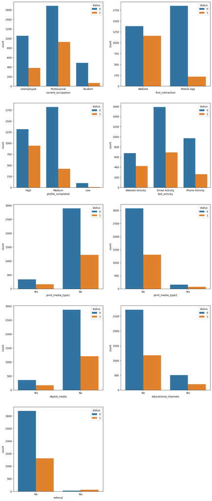

```python
# Select columns of type object (string) or category
categorical_vars = list(data.select_dtypes(include=['object', 'category']).columns)

# Determine bounds
num_plots = len(categorical_vars)
total_cols = 2
total_rows = math.ceil(num_plots/total_cols)

# Size subplots dynamically
fig, axs = plt.subplots(nrows=total_rows, ncols=total_cols,
                        figsize=(7*total_cols, 7*total_rows), constrained_layout=False)

# Render countplots, with hue
for i, var in enumerate(categorical_vars):
    row = i//total_cols
    pos = i % total_cols

    if (i < len(categorical_vars)): plot = sns.countplot(x=var, data=data, ax=axs[row][pos], hue='status')

# Delete extraneous subplot
fig.delaxes(axs[total_rows-1][total_cols-1])
```

Observations: **bold text**Based on the visualization, we can answer some of the questions asked initially

To better estimate conversion rates in relation to advertising channels, we can calculate the raw conversion rate for each channel.

This will not provide conclusive indications however, in part because conversion rates could depend on users having been reached through multiple channels. For this, we should consider feature engineering, and further study.

However it will help to highlight the impact of each individual channel among converted users.

```python
advertising_channels = ['print_media_type1', 'print_media_type2', 'digital_media', 'educational_channels', 'referral']
d = []

for channel in advertising_channels:
    # Users who have seen the ad in channel
    have_seen = data[data[channel]=='Yes']
    # Counts of converted (1) vs. non-converted (0) users
    counts = have_seen['status'].value_counts(normalize = True)
    # Conversion rate (channel-local)
    d.append(counts[1])

display(pd.DataFrame(d, columns=['conversion_rate'], index=advertising_channels).sort_values(by='conversion_rate', ascending=False))
```

|  | conversion_rate |
| --- | --- |
| referral | 0.677419 |
| print_media_type2 | 0.321888 |
| print_media_type1 | 0.319920 |
| digital_media | 0.318786 |
| educational_channels | 0.279433 |

**Bi-variate Anaysis:** Plotting of correlation matrix using heatmap from seaborn library using Spearman's Rank in an attempt to emphasize possible correlations.

```python
num_cols = data[['age', 'website_visits', 'time_spent_on_website','page_views_per_visit', 'status']]
```

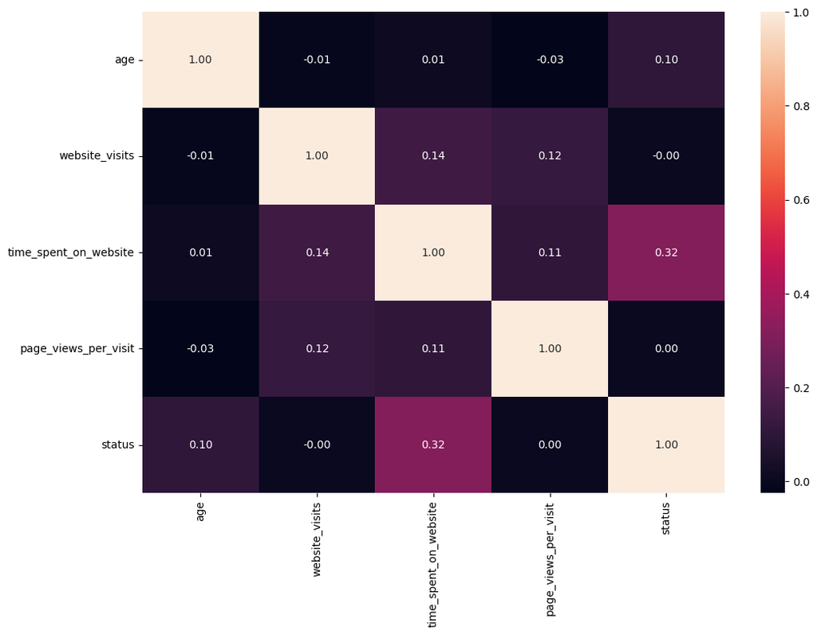

```python
plt.figure(figsize=(12, 8))
sns.heatmap(num_cols.corr(method='spearman'), annot = True, fmt = '.2f')
plt.show()
```

Observation:

With this approach, we find that only time spent on the website and status exhibit a notable - but weak - positive correlation. Further study is required.

Correlation between Status and current occupation type

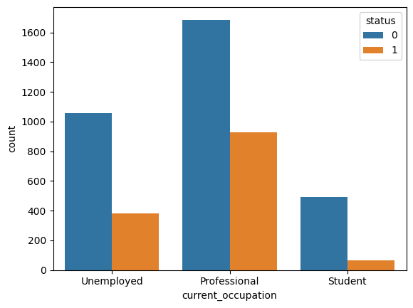

```python
sns.countplot(data = data, x = 'current_occupation', hue = 'status')

plt.show()
```

**Observation**: As observed earlier, working professionals have highest conversion rate , followed by uneployed. Students have the least conversion rate. This appears to align with the intended objective of providing courses for reskilling or upskilling, as well potentially as with the availability of financial means to shoulder tuition fees.

**Bivariate analysis of Age and Current occupation**

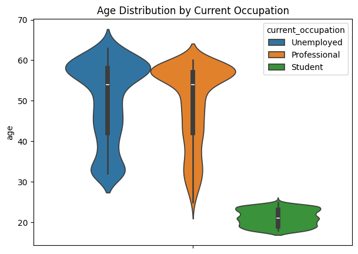

```python
plt.figure(figsize=(7, 5))
sns.violinplot(data = data, y = 'age', hue = 'current_occupation', split = False)
plt.title('Age Distribution by Current Occupation')
plt.show()
```

```python
data.groupby('current_occupation')['age'].describe()
```

| current_occupation | count | mean | std | min | 25% | 50% | 75% | max |
| --- | --- | --- | --- | --- | --- | --- | --- | --- |
| Professional | 2616.0 | 49.347477 | 9.890744 | 25.0 | 42.0 | 54.0 | 57.0 | 60.0 |
| Student | 555.0 | 21.144144 | 2.001114 | 18.0 | 19.0 | 21.0 | 23.0 | 25.0 |
| Unemployed | 1441.0 | 50.140180 | 9.999503 | 32.0 | 42.0 | 54.0 | 58.0 | 63.0 |

**Observations**:

There is a notable skew toward 57-58 years of age among both the professional and unemployed categories, with also similar spread between the two (min 25 and 32, max 60 and 63 resp). Ages are distributed approximately uniformly between 18 and 25 years for students. This suggests that the offering has strong late-career appeal among all leads.

**Analysing other variables**

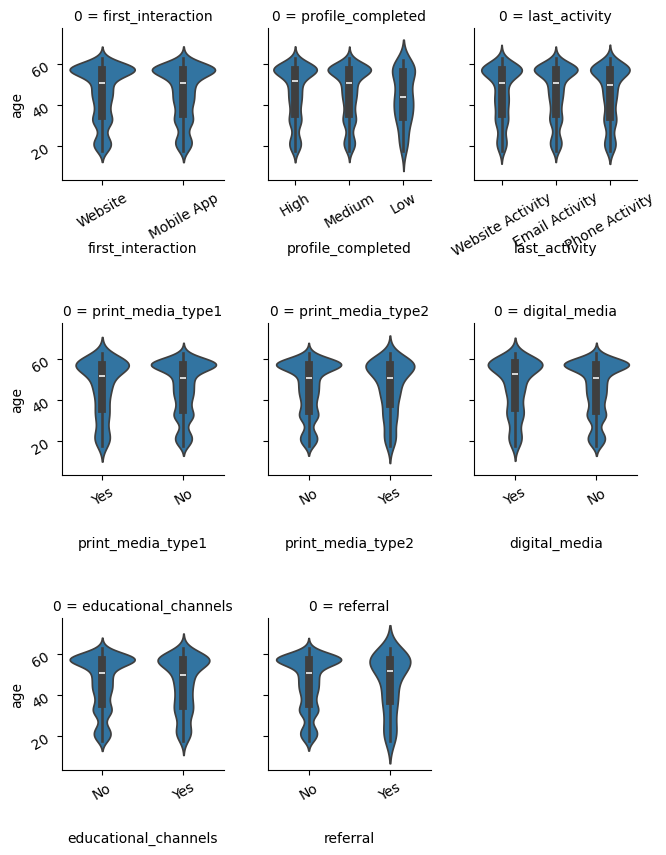

```python
# Select categorical vars which might be significant
bivariates_of_age = ['first_interaction', 'profile_completed', 'last_activity', 'print_media_type1', 'print_media_type2', 'digital_media', 'educational_channels', 'referral']

# Plot age correlation as a grid of violin plots
g = sns.FacetGrid(pd.DataFrame(bivariates_of_age), col=0, col_wrap=3, aspect=0.75, sharex=False)
for ax, x_var in zip(g.axes, bivariates_of_age):
    sns.violinplot(data=data, x=x_var, y='age', ax=ax)
    # Position primary x labels
    ax.get_xaxis().set_label_coords(0.5,-0.4)

g.tight_layout()

# Rotate secondary labels
for ax in g.axes.flatten():
    ax.tick_params(rotation = 30)
```

**Observation:**

**Status and Time Spent on Website** Earlier we've noted a possible correlation between status (converted leads), and time spent on website. So we will explore this relationship.

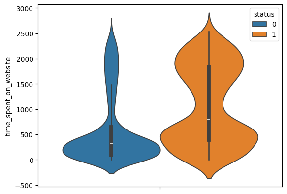

```python
sns.violinplot(data = data, y = 'time_spent_on_website', hue = 'status')
plt.show()
```

**Observations**:

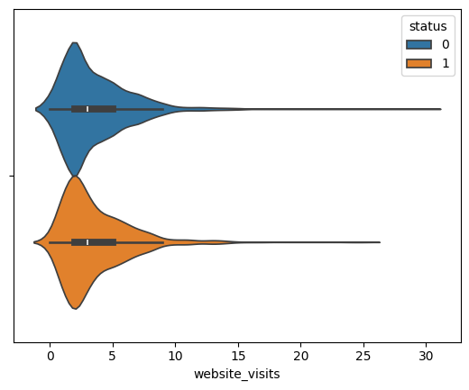

```python
sns.violinplot(data = data, x = 'website_visits', hue = 'status', )
plt.show()
```

```python
data_pc = data.groupby('profile_completed')['status'].value_counts()
```

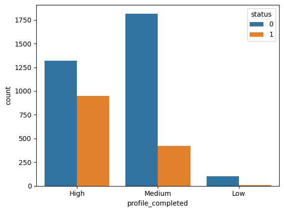

```python
data_pc = data.groupby('profile_completed')['status'].value_counts().reset_index(name='count')
#sns.barplot(data=data_pc, x='profile_completed', y='count', hue='status')
sns.countplot(data=data, x='profile_completed', hue='status')
#plt.show()
plt.show()
```

**Observation** he plot suggests that leads with 'High' profile completion have a better chance of converting compared to those with 'Low' or 'Medium' completion. While 'Medium' completion has many non-converted leads, the proportion of converted leads is higher than in the 'Low' category. This aligns with the earlier observation that having more details about a prospect might increase the chances of conversion.

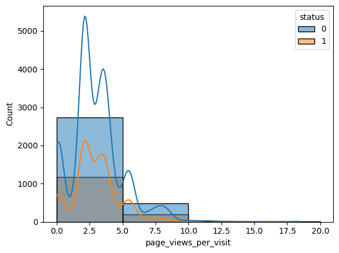

```python
bin_edges = [0, 5, 10, 15, 20] # Example bin edges
sns.histplot(data=data, x='page_views_per_visit', hue='status', kde=True, bins=bin_edges)
plt.show()
```

## Data Preprocessing

- We will have to encode categorical features.
- Decision trees and random forest are considered robust to outliers.
- We will split the data between train and test datasets.

```python
# Checking missing values
data.isna().sum()
```

|  | 0 |
| --- | --- |
| age | 0 |
| current_occupation | 0 |
| first_interaction | 0 |
| profile_completed | 0 |
| website_visits | 0 |
| time_spent_on_website | 0 |
| page_views_per_visit | 0 |
| last_activity | 0 |
| print_media_type1 | 0 |
| print_media_type2 | 0 |
| digital_media | 0 |
| educational_channels | 0 |
| referral | 0 |
| status | 0 |

**dtype:** int64

**Missing value check**

1. There are no missing values in the data.

```python
# Splitting the target feature i.e. status

X = data.drop(columns = 'status')

Y = data['status']
```

```python
# Categorical variables are encoded as dummies
X = pd.get_dummies(X, drop_first = True)
```

```python
X.head()
```

|  | age | website_visits | time_spent_on_website | page_views_per_visit | current_occupation_Student | current_occupation_Unemployed | first_interaction_Website | profile_completed_Low | profile_completed_Medium | last_activity_Phone Activity | last_activity_Website Activity | print_media_type1_Yes | print_media_type2_Yes | digital_media_Yes | educational_channels_Yes | referral_Yes |
| --- | --- | --- | --- | --- | --- | --- | --- | --- | --- | --- | --- | --- | --- | --- | --- | --- |
| 0 | 57 | 7 | 1639 | 1.861 | False | True | True | False | False | False | True | True | False | True | False | False |
| 1 | 56 | 2 | 83 | 0.320 | False | False | False | False | True | False | True | False | False | False | True | False |
| 2 | 52 | 3 | 330 | 0.074 | False | False | True | False | True | False | True | False | False | True | False | False |
| 3 | 53 | 4 | 464 | 2.057 | False | True | True | False | False | False | True | False | False | False | False | False |
| 4 | 23 | 4 | 600 | 16.914 | True | False | True | False | False | False | False | False | False | False | False | False |

**Split the data into train and test sets**

```python
X_train, X_test , y_train, y_test = train_test_split(X, Y, test_size = 0.2, random_state = 42)
```

**Checking structure of data again**

```python
X_train
```

|  | age | website_visits | time_spent_on_website | page_views_per_visit | current_occupation_Student | current_occupation_Unemployed | first_interaction_Website | profile_completed_Low | profile_completed_Medium | last_activity_Phone Activity | last_activity_Website Activity | print_media_type1_Yes | print_media_type2_Yes | digital_media_Yes | educational_channels_Yes | referral_Yes |
| --- | --- | --- | --- | --- | --- | --- | --- | --- | --- | --- | --- | --- | --- | --- | --- | --- |
| 3388 | 56 | 8 | 1673 | 3.667 | False | False | True | True | False | False | True | True | False | False | False | False |
| 2002 | 19 | 3 | 95 | 2.109 | True | False | False | False | False | True | False | False | False | False | False | True |
| 1891 | 43 | 8 | 1351 | 4.842 | False | False | False | False | False | False | False | False | True | False | False | True |
| 2764 | 45 | 5 | 255 | 5.631 | False | False | True | False | False | False | False | False | False | False | False | False |
| 4043 | 59 | 6 | 1254 | 5.174 | False | True | False | False | True | True | False | False | False | True | False | False |
| ... | ... | ... | ... | ... | ... | ... | ... | ... | ... | ... | ... | ... | ... | ... | ... | ... |
| 4426 | 43 | 5 | 2245 | 3.730 | False | True | True | False | False | True | False | False | False | False | False | False |
| 466 | 57 | 5 | 586 | 5.746 | False | False | True | False | False | False | False | False | False | False | False | False |
| 3092 | 62 | 1 | 168 | 3.356 | False | True | True | False | True | True | False | False | False | False | False | True |
| 3772 | 43 | 4 | 2170 | 3.572 | False | False | False | False | False | True | False | False | False | False | False | False |
| 860 | 56 | 1 | 603 | 3.599 | False | False | True | False | False | False | False | False | False | False | False | False |

3689 rows × 16 columns

```python
X_train.shape
```

```
(3689, 16)
```

```python
X_train.dtypes.value_counts()
```

|  | count |
| --- | --- |
| bool | 12 |
| int64 | 3 |
| float64 | 1 |

**dtype:** int64

```python
X_train.describe(include = 'all').T
```

|  | count | unique | top | freq | mean | std | min | 25% | 50% | 75% | max |
| --- | --- | --- | --- | --- | --- | --- | --- | --- | --- | --- | --- |
| age | 3689.0 | NaN | NaN | NaN | 46.275413 | 13.19323 | 18.0 | 36.0 | 51.0 | 57.0 | 63.0 |
| website_visits | 3689.0 | NaN | NaN | NaN | 3.563567 | 2.834907 | 0.0 | 2.0 | 3.0 | 5.0 | 30.0 |
| time_spent_on_website | 3689.0 | NaN | NaN | NaN | 731.427216 | 746.790049 | 0.0 | 154.0 | 380.0 | 1354.0 | 2537.0 |
| page_views_per_visit | 3689.0 | NaN | NaN | NaN | 3.014325 | 1.952144 | 0.0 | 2.074 | 2.767 | 3.75 | 18.434 |
| current_occupation_Student | 3689 | 2 | False | 3245 | NaN | NaN | NaN | NaN | NaN | NaN | NaN |
| current_occupation_Unemployed | 3689 | 2 | False | 2520 | NaN | NaN | NaN | NaN | NaN | NaN | NaN |
| first_interaction_Website | 3689 | 2 | True | 2029 | NaN | NaN | NaN | NaN | NaN | NaN | NaN |
| profile_completed_Low | 3689 | 2 | False | 3599 | NaN | NaN | NaN | NaN | NaN | NaN | NaN |
| profile_completed_Medium | 3689 | 2 | False | 1904 | NaN | NaN | NaN | NaN | NaN | NaN | NaN |
| last_activity_Phone Activity | 3689 | 2 | False | 2709 | NaN | NaN | NaN | NaN | NaN | NaN | NaN |
| last_activity_Website Activity | 3689 | 2 | False | 2805 | NaN | NaN | NaN | NaN | NaN | NaN | NaN |
| print_media_type1_Yes | 3689 | 2 | False | 3294 | NaN | NaN | NaN | NaN | NaN | NaN | NaN |
| print_media_type2_Yes | 3689 | 2 | False | 3505 | NaN | NaN | NaN | NaN | NaN | NaN | NaN |
| digital_media_Yes | 3689 | 2 | False | 3272 | NaN | NaN | NaN | NaN | NaN | NaN | NaN |
| educational_channels_Yes | 3689 | 2 | False | 3108 | NaN | NaN | NaN | NaN | NaN | NaN | NaN |
| referral_Yes | 3689 | 2 | False | 3608 | NaN | NaN | NaN | NaN | NaN | NaN | NaN |

```python
print('Shape of training set: ', X_train.shape)

print('Shape of test set: ', X_test.shape)

print('Target classes distribution in training set:')

print(y_train.value_counts(normalize = True))

print('Target classes distribution in test set:')

print(y_test.value_counts(normalize = True))
```

```
Shape of training set:  (3689, 16)
Shape of test set:  (923, 16)
Target classes distribution in training set:
status
0    0.701003
1    0.298997
Name: proportion, dtype: float64
Target classes distribution in test set:
status
0    0.703142
1    0.296858
Name: proportion, dtype: float64
```

```python
X_train.head()
```

|  | age | website_visits | time_spent_on_website | page_views_per_visit | current_occupation_Student | current_occupation_Unemployed | first_interaction_Website | profile_completed_Low | profile_completed_Medium | last_activity_Phone Activity | last_activity_Website Activity | print_media_type1_Yes | print_media_type2_Yes | digital_media_Yes | educational_channels_Yes | referral_Yes |
| --- | --- | --- | --- | --- | --- | --- | --- | --- | --- | --- | --- | --- | --- | --- | --- | --- |
| 3388 | 56 | 8 | 1673 | 3.667 | False | False | True | True | False | False | True | True | False | False | False | False |
| 2002 | 19 | 3 | 95 | 2.109 | True | False | False | False | False | True | False | False | False | False | False | True |
| 1891 | 43 | 8 | 1351 | 4.842 | False | False | False | False | False | False | False | False | True | False | False | True |
| 2764 | 45 | 5 | 255 | 5.631 | False | False | True | False | False | False | False | False | False | False | False | False |
| 4043 | 59 | 6 | 1254 | 5.174 | False | True | False | False | True | True | False | False | False | True | False | False |

```python
X_test.head()
```

|  | age | website_visits | time_spent_on_website | page_views_per_visit | current_occupation_Student | current_occupation_Unemployed | first_interaction_Website | profile_completed_Low | profile_completed_Medium | last_activity_Phone Activity | last_activity_Website Activity | print_media_type1_Yes | print_media_type2_Yes | digital_media_Yes | educational_channels_Yes | referral_Yes |
| --- | --- | --- | --- | --- | --- | --- | --- | --- | --- | --- | --- | --- | --- | --- | --- | --- |
| 1073 | 23 | 7 | 243 | 3.512 | True | False | False | False | False | False | False | False | False | False | False | False |
| 2749 | 32 | 0 | 0 | 0.000 | False | False | False | False | True | False | False | False | False | False | False | False |
| 1374 | 45 | 2 | 179 | 5.483 | False | True | False | False | True | False | False | True | False | False | True | False |
| 4484 | 35 | 7 | 56 | 3.985 | False | False | True | True | False | True | False | False | False | False | False | False |
| 3824 | 24 | 2 | 2275 | 3.141 | True | False | False | False | True | False | False | False | False | False | False | False |

**Observations**:

```python
# Creating metric function

def metrics_score(actual, predicted):

    print(classification_report(actual, predicted))

    cm = confusion_matrix(actual, predicted)

    plt.figure(figsize = (8, 5))

    sns.heatmap(cm, annot = True, fmt = '.2f', xticklabels = ['Not Converting', 'Converting'], yticklabels = ['Not Converting', 'Converting'])
    plt.ylabel('Actual')

    plt.xlabel('Predicted')

    plt.show()
```

```python
 def model_performance_classification(model, predictors, target):
    """
    Function to compute different metrics to check classification model performance

    model: classifier

    predictors: independent variables

    target: dependent variable
    """

    # Predicting using the independent variables
    pred = model.predict(predictors)

    recall = recall_score(target, pred,average = 'macro')                 # To compute recall

    precision = precision_score(target, pred, average = 'macro')              # To compute precision

    acc = accuracy_score(target, pred)                                 # To compute accuracy score


    # Creating a dataframe of metrics

    df_perf = pd.DataFrame(
        {
            "Precision":  precision,
            "Recall":  recall,
            "Accuracy": acc,
        },

        index = [0],
    )

    return df_perf
```

## Building a Decision Tree model

```python
# Building decision tree model
dt = DecisionTreeClassifier(class_weight = {0: 0.17, 1: 0.83}, random_state = 1)
```

```python
#fitting a decision tree
dt.fit(X_train, y_train)
```

```
DecisionTreeClassifier(class_weight={0: 0.17, 1: 0.83}, random_state=1)
```

**Checking the model performance of decision tree**

## Model Performance evaluation and improvement

```
              precision    recall  f1-score   support

           0       1.00      1.00      1.00      2586
           1       1.00      1.00      1.00      1103

    accuracy                           1.00      3689
   macro avg       1.00      1.00      1.00      3689
weighted avg       1.00      1.00      1.00      3689
```

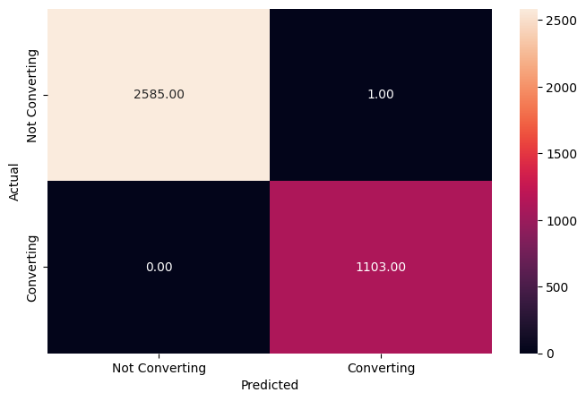

```python
#Checking the model performance of the training dataset
y_train_pred= dt.predict(X_train)
metrics_score(y_train, y_train_pred)
```

All the performace values, i.e. precision, Recall, and F1-score, are all one which means the model has achieved the perfect precision and accuracy. 2585 (**True** **Negative**) will not attriate and 1103(**True Positive**) will attriate there is no or zero **false negative. ** The model has achieved perfect performance training data. Althought this is an ideal performance, but this might be a case of overfitting. Overfitting means training data fits too well, even including the noise and specific patters of the training set which can be misleading for the the test data.

```
              precision    recall  f1-score   support

           0       0.86      0.89      0.87       649
           1       0.71      0.65      0.68       274

    accuracy                           0.82       923
   macro avg       0.78      0.77      0.78       923
weighted avg       0.81      0.82      0.81       923
```

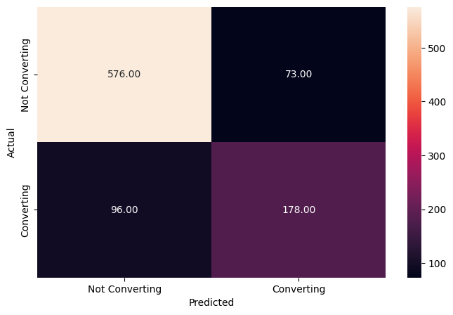

```python
#Checking the model performance  for the testing data
y_test_pred= dt.predict(X_test)
metrics_score(y_test, y_test_pred)
```

```python
dtree_test = model_performance_classification(dt,X_test,y_test)
dtree_test
```

|  | Precision | Recall | Accuracy |
| --- | --- | --- | --- |
| 0 | 0.783153 | 0.768577 | 0.816901 |

**Observation:** **Precision, Recall, and F1-score:**  
**Class 0** (Not Converting):  
Precision: 0.86 (86% of leads predicted as not converting actually didn't convert)  
Recall: 0.89 (89% of leads that didn't convert were correctly identified)  
F1-score: 0.87 (Harmonic mean of precision and recall for class 0)  
**Class 1** (Converting):  
Precision: 0.71 (71% of leads predicted as converting actually converted)  
**Recall**: 0.65 (65% of leads that converted were correctly identified)  
**F1-score:** 0.68 (Harmonic mean of precision and recall for class 1)  
Compared to the perfect performance on the training data, the performance on the test data is significantly lower. This confirms the overfitting we suspected. The model learned the training data too specifically and is not generalizing as well to new, unseen data.

Specifically, the model is better at predicting leads that will not convert (Class 0) than leads that will convert (Class 1). The lower recall for Class 1 (0.65) means that the model missed about 35% of the leads that actually converted (resulting in 96 False Negatives). This is important because identifying leads who are likely to convert is crucial for the company's objective.

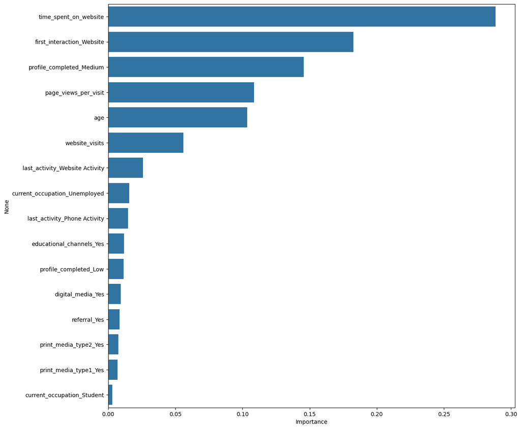

```python
# Plot the feature importance

importances = dt.feature_importances_

columns = X.columns

importance_df = pd.DataFrame(importances, index = columns, columns = ['Importance']).sort_values(by = 'Importance', ascending = False)

plt.figure(figsize = (13, 13))

sns.barplot(x=importance_df.Importance,y=importance_df.index);
```

**Observations**:

1. Time Spent on Website is the most important feature. This indicates the longer the lead spends time on website, the more are the chances to join the course
2. First_interaction_website is the second most important feature, followed by profile completed medium and page_views_per_visit. These features also result in higher likelihood of conversion.

This information can be valuable for ExtraaLearn to focus their efforts on improving the website experience and encouraging leads to spend more time and engage more deeply with the content.

**HyperParameter Tuning** The criterion is to measure the quality of a split. Supported criteria are “gini” for the Gini impurity and “entropy” for the information gain. The GridSearch function is used for hyperparameter tuning

max_depth

```python
# Choose the type of classifier
dtree_estimator = DecisionTreeClassifier(class_weight = {0: 0.17, 1: 0.83}, random_state = 1)

# Grid of parameters to choose from
parameters = {'max_depth': np.arange(2, 7),
              'criterion': ['gini', 'entropy'],
              'min_samples_leaf': [5, 10, 20, 25]
             }

# Type of scoring used to compare parameter combinations
scorer = metrics.make_scorer(recall_score, pos_label = 1)

# Run the grid search
gridCV = GridSearchCV(dtree_estimator, parameters, scoring = scorer, cv = 10)

# Fitting the grid search on the train data
gridCV = gridCV.fit(X_train, y_train)

# Set the classifier to the best combination of parameters
dtree_estimator = gridCV.best_estimator_

# Fit the best estimator to the data
dtree_estimator.fit(X_train, y_train)
```

```
DecisionTreeClassifier(class_weight={0: 0.17, 1: 0.83}, max_depth=np.int64(2),
                       min_samples_leaf=5, random_state=1)
```

```
              precision    recall  f1-score   support

           0       0.99      0.35      0.52      2586
           1       0.40      0.99      0.57      1103

    accuracy                           0.54      3689
   macro avg       0.69      0.67      0.54      3689
weighted avg       0.81      0.54      0.53      3689
```

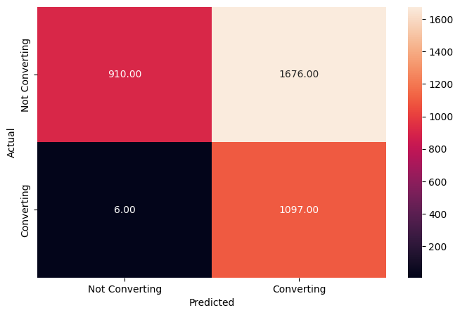

```python
y_train_pred= dtree_estimator.predict(X_train)
metrics_score(y_train, y_train_pred)
```

After hyperparameter tuning, the model's performance on the training data shows a trade-off. It has become very effective at identifying nearly all of the converting leads (high recall for Class 1), but it also incorrectly flags a large number of non-converting leads as potential converters (high number of False Positives for Class 0 and low recall for Class 0).

This contrasts with the initial untuned model, which had perfect scores on the training data due to overfitting. The tuned model is no longer perfectly fitting the training data but is instead showing a performance profile that is likely influenced by the hyperparameter tuning process, particularly if class weights were used to prioritize identifying the minority class (converting leads).

```
              precision    recall  f1-score   support

           0       1.00      0.36      0.53       649
           1       0.40      1.00      0.57       274

    accuracy                           0.55       923
   macro avg       0.70      0.68      0.55       923
weighted avg       0.82      0.55      0.54       923
```

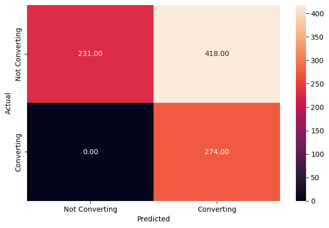

```python
y_test_pred = dtree_estimator.predict(X_test)
metrics_score(y_test, y_test_pred)
```

```python
dtree_tuned_test = model_performance_classification(dtree_estimator,X_test,y_test)
dtree_tuned_test
```

|  | Precision | Recall | Accuracy |
| --- | --- | --- | --- |
| 0 | 0.697977 | 0.677966 | 0.547129 |

**Precision**: The tuned Decision Tree has a lower precision (0.698) compared to the untuned Decision Tree (0.783).  
**Recall**: The tuned Decision Tree also has a lower recall (0.678) compared to the untuned Decision Tree (0.769). Correction: In a previous turn, the recall for the tuned Decision Tree on the test set from the metrics_score output was 1.00 for Class 1. The model_performance_classification function calculates macro average recall, which is why the value here is lower. The macro average recall considers the recall of both classes equally.  
**Accuracy**: The tuned Decision Tree has significantly lower accuracy (0.547) compared to the untuned Decision Tree (0.817).

Based on the macro average metrics provided by model_performance_classification, the untuned Decision Tree appears to perform better on the test data in terms of overall precision, recall, and accuracy.

It's important to note the difference between the macro average recall shown here and the recall for a specific class (like Class 1) shown in the classification_report output from the metrics_score function. The model_performance_classification function provides a summary across both classes, while the metrics_score function provides detailed metrics for each class individually.

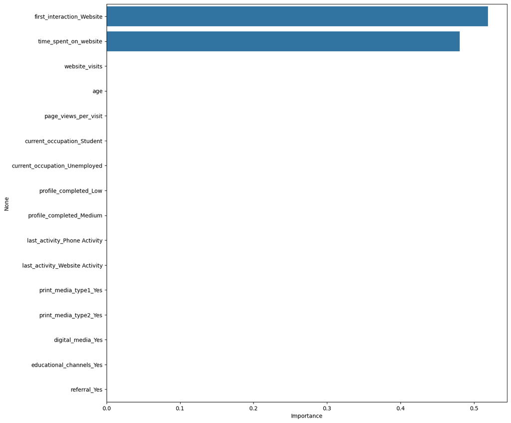

```python
importances = dtree_estimator.feature_importances_

columns = X.columns

importance_df = pd.DataFrame(importances, index = columns, columns = ['Importance']).sort_values(by = 'Importance', ascending = False)

plt.figure(figsize = (13, 13))

sns.barplot(x= importance_df.Importance, y= importance_df.index);
```

The barplot shows that first interaction with the website and , total minutes spent on websit are the most influential in determining that the lead would convert.

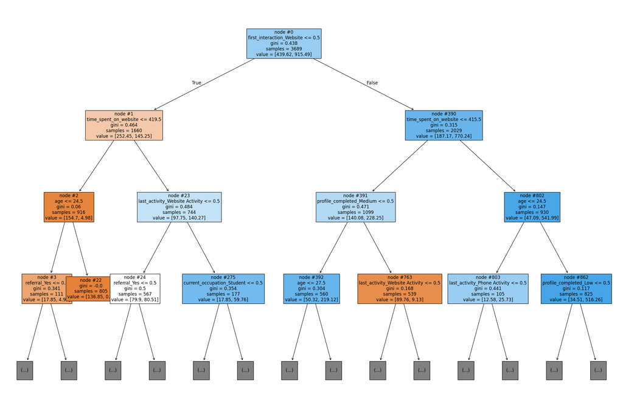

```python
features = list(X.columns)

plt.figure(figsize = (30, 20))

tree.plot_tree(dt, max_depth = 3, feature_names = features, filled = True, fontsize = 12, node_ids = True, class_names = None)

plt.show()
```

**Observations:**

1. The root node is first interaction with website <=0.5, this tis the starting node and results in hightest infromation gain.
2. It further checks for if time spent on website . The blue nodes shows the leads is positive or is converted the orange node shows that the lead has not converted .
3. It shows that those who spent time more than 415 minutes, they have joined the course.
4. Among leads who have first interacted through the website, those who do not have medium profile completeness are also likely to convert.
5. Leads who have not interacted through website the first time, but have spent more than 419.5 s on the website and have last interaction through website are also likely to convert.

## Building a Random Forest model

```python
# Fitting the Random Forest classifier on the training data
rf_estimator = RandomForestClassifier(class_weight = {0: 0.17, 1: 0.83}, random_state = 1)

rf_estimator.fit(X_train, y_train)
```

```
RandomForestClassifier(class_weight={0: 0.17, 1: 0.83}, random_state=1)
```

```
              precision    recall  f1-score   support

           0       1.00      1.00      1.00      2586
           1       1.00      1.00      1.00      1103

    accuracy                           1.00      3689
   macro avg       1.00      1.00      1.00      3689
weighted avg       1.00      1.00      1.00      3689
```

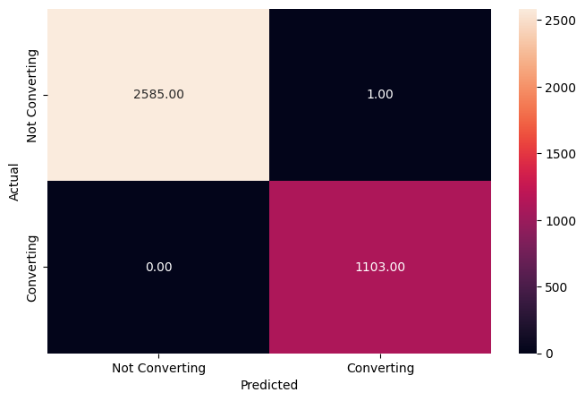

```python
# Checking performance on the training data
y_pred_train_rf = rf_estimator.predict(X_train)

metrics_score(y_train, y_pred_train_rf)
```

The Random Forest is giving a 100% score for all metrics on the training dataset.

```
              precision    recall  f1-score   support

           0       0.87      0.94      0.90       649
           1       0.82      0.68      0.74       274

    accuracy                           0.86       923
   macro avg       0.85      0.81      0.82       923
weighted avg       0.86      0.86      0.86       923
```

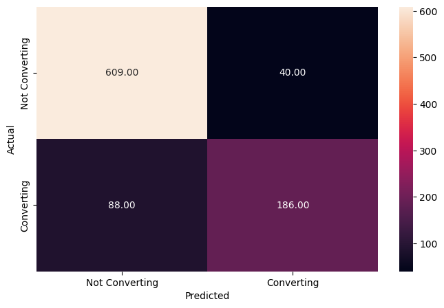

```python
# Checking performance on the testing data
y_pred_test_rf = rf_estimator.predict(X_test)

metrics_score(y_test, y_pred_test_rf)
```

Random Forest DT overfits on the training data as recall is 1 for the training set while it is only 68% for the test set. F1 and Precision also vary a lot

```python
rf_estimator_train = model_performance_classification(rf_estimator,X_train,y_train)
rf_estimator_train
```

|  | Precision | Recall | Accuracy |
| --- | --- | --- | --- |
| 0 | 0.999547 | 0.999807 | 0.999729 |

```python
rf_estimator_test = model_performance_classification(rf_estimator,X_test,y_test)
rf_estimator_test
```

|  | Precision | Recall | Accuracy |
| --- | --- | --- | --- |
| 0 | 0.848377 | 0.808599 | 0.861322 |

Ransom Forest model also seems to overfit too, but it has improved a bit. It also fit well on the test data.

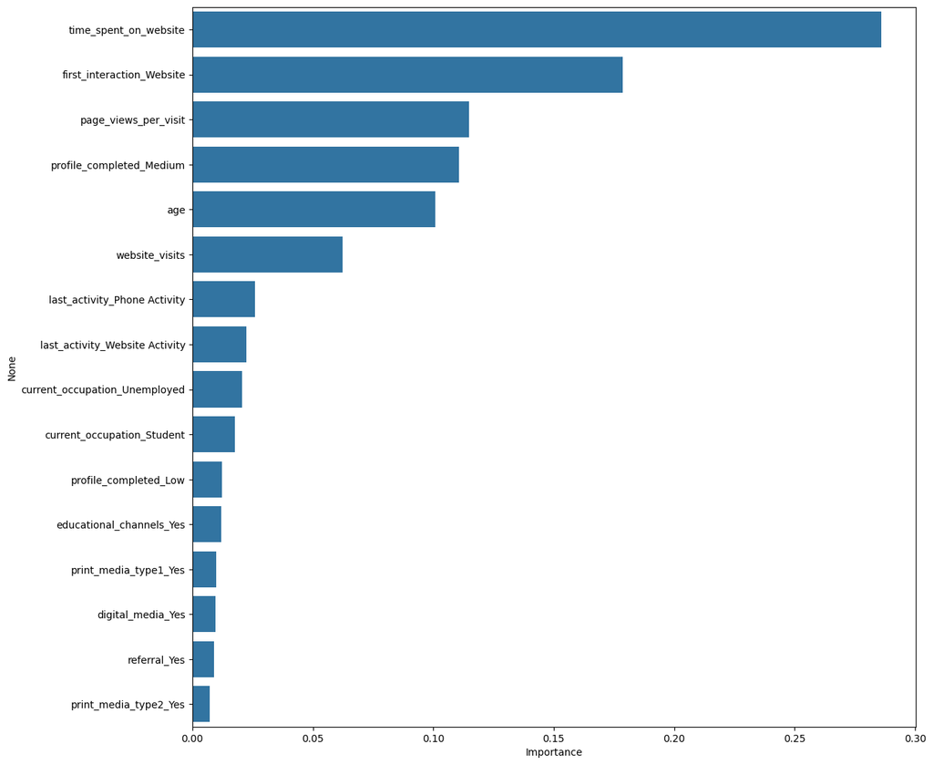

```python
importances = rf_estimator.feature_importances_

columns = X.columns

importance_df = pd.DataFrame(importances, index = columns, columns = ['Importance']).sort_values(by = 'Importance', ascending = False)

plt.figure(figsize = (13, 13))

sns.barplot(x= importance_df.Importance, y=importance_df.index);
```

## Model Performance evaluation and improvement

```python
# Choose the type of classifier
rf_estimator_tuned = RandomForestClassifier(class_weight = {0: 0.17, 1: 0.83}, random_state = 1)

# Grid of parameters to choose from
params_rf = {
        "n_estimators": [100, 250, 500],
        "min_samples_leaf": np.arange(1, 4, 1),
        "max_features": [0.7, 0.9, 'auto'],
}


# Type of scoring used to compare parameter combinations - recall score for class 1
scorer = metrics.make_scorer(recall_score, pos_label = 1)

# Run the grid search
grid_obj = GridSearchCV(rf_estimator_tuned, params_rf, scoring = scorer, cv = 5)

grid_obj = grid_obj.fit(X_train, y_train)

# Set the classifier to the best combination of parameters
rf_estimator_tuned = grid_obj.best_estimator_
```

```python
rf_estimator_tuned.fit(X_train, y_train)
```

```
RandomForestClassifier(class_weight={0: 0.17, 1: 0.83}, max_features=0.7,
                       min_samples_leaf=np.int64(3), random_state=1)
```

```
              precision    recall  f1-score   support

           0       1.00      0.93      0.96      2586
           1       0.85      1.00      0.92      1103

    accuracy                           0.95      3689
   macro avg       0.93      0.96      0.94      3689
weighted avg       0.96      0.95      0.95      3689
```

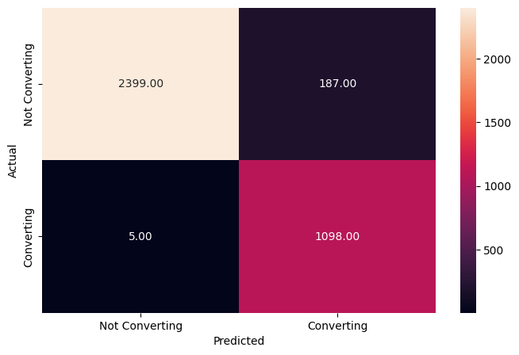

```python
# Checking performance on the training data
y_pred_train_rf_tuned = rf_estimator_tuned.predict(X_train)

metrics_score(y_train, y_pred_train_rf_tuned)
```

```
              precision    recall  f1-score   support

           0       0.92      0.90      0.91       649
           1       0.77      0.81      0.79       274

    accuracy                           0.87       923
   macro avg       0.84      0.85      0.85       923
weighted avg       0.87      0.87      0.87       923
```

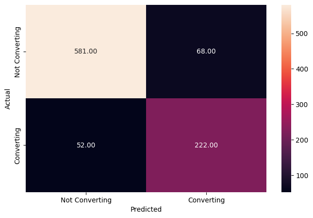

```python
# Checking performance on the test data
y_pred_test_rf_tuned = rf_estimator_tuned.predict(X_test)

metrics_score(y_test, y_pred_test_rf_tuned)
```

**Observation**

The tuned model is also slightly overfitting the training dataset, but it shows a good performance on the test dataset.  
The recall for class 1 has improved with a small decrease in precision.  
This model is the best-performing one among all the models so far, and is giving us good precision and recall scores on the test dataset.

```python
rf_estimator_tuned_test = model_performance_classification(rf_estimator_tuned,X_test,y_test)
rf_estimator_tuned_test
```

|  | Precision | Recall | Accuracy |
| --- | --- | --- | --- |
| 0 | 0.841684 | 0.852721 | 0.869989 |

The tuned random forest model shows a better performance than decision tree or tuned decision tree models

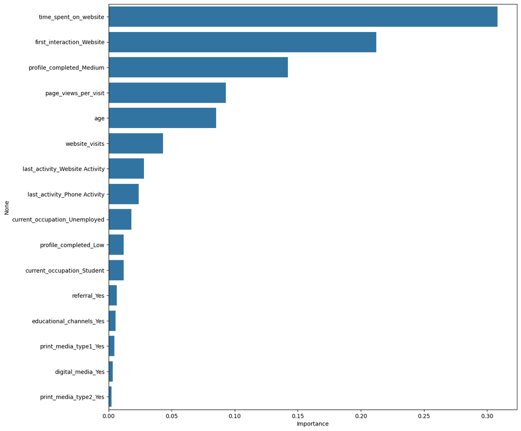

```python
# Plotting feature importance
importances = rf_estimator_tuned.feature_importances_

columns = X.columns

importance_df = pd.DataFrame(importances, index = columns, columns = ['Importance']).sort_values(by = 'Importance', ascending = False)

plt.figure(figsize = (13, 13))

sns.barplot(x= importance_df.Importance, y= importance_df.index)
```

Observations:

The feature importance plot for the base model and tuned model are quite similar. The model seems to suggest that Time spent on websitd and first interaction are the most important features.  
Other important features are profile completion_medium, pages per view and age are some other important factors too, referals have also gained more importance on some of the other factors.

## Actionable Insights and Recommendations

Based on feature importance from classification as well as EDA, factors contributing to conversion seem to be:

**Time spent on the website** Having one's **first interaction through the website** **Profile completeness** at or above medium Followed by: **Professional activity **(non-student) **Age** (toward late career) **Last activity was through the website** Also: **Referrals** could be playing a role into the conversion decision. Based on these, leads most likely to convert are late-career professionals, employed or unemployed, who have engaged with and spent significant time on the website, and possibly completed their profile.

EDA however has indicated some problems:

The impact of advertising channels is not represented well in the model, with insufficient sample sizes. The data also doesn't describe possible correlations and the combined effects of multiple advertising channels. Conversion rates among leads who have joined without visiting the website are lower than the average. Conversion rates among leads who have interacted first with the mobile application are significantly lower. The data doesn't provide indications about how time is spent on the website.

```python
!pip install xgboost
```

```python
# Importing the AdaBoostClassifier and GradientBoostingClassifier [Boosting]
from sklearn.ensemble import AdaBoostClassifier, GradientBoostingClassifier

# Importing the XGBClassifier from the xgboost library
from xgboost import XGBClassifier
```

```python
# Adaboost Classifier
adaboost_model = AdaBoostClassifier(random_state = 1)

# Fitting the model
adaboost_model.fit(X_train, y_train)

# Model Performance on the test data
adaboost_model_perf_test = model_performance_classification(adaboost_model,X_test,y_test)


adaboost_model_perf_test
```

|  | Precision | Recall | Accuracy |
| --- | --- | --- | --- |
| 0 | 0.792947 | 0.747489 | 0.816901 |

```python
# Gradient Boost Classifier
gbc = GradientBoostingClassifier(random_state = 1)

# Fitting the model
gbc.fit(X_train, y_train)

# Model Performance on the test data
gbc_perf_test = model_performance_classification(gbc, X_test, y_test)

gbc_perf_test
```

|  | Precision | Recall | Accuracy |
| --- | --- | --- | --- |
| 0 | 0.838942 | 0.82624 | 0.862405 |

```python
# XGBoost Classifier
xgb = XGBClassifier(random_state = 1, eval_metric = 'logloss')

# Fitting the model
xgb.fit(X_train,y_train)

# Model Performance on the test data
xgb_perf_test = model_performance_classification(xgb,X_test,y_test)

xgb_perf_test
```

|  | Precision | Recall | Accuracy |
| --- | --- | --- | --- |
| 0 | 0.833688 | 0.809249 | 0.854821 |

```python
models_test_comp_df = pd.concat(

    [
    dtree_test.T, dtree_tuned_test.T,rf_estimator_test.T,
    rf_estimator_tuned_test.T, adaboost_model_perf_test.T,
    gbc_perf_test.T, xgb_perf_test.T
    ],

    axis = 1,
)

models_test_comp_df.columns = [
    "Decision Tree classifier",
    "Tuned Decision Tree classifier",
    "Random Forest classifier",
    "Tuned Random Forest classifier",
    "Adaboost classifier",
    "Gradientboost classifier",
    "XGBoost classifier"
]

print("Test performance comparison:")
```

```
Test performance comparison:
```

```python
models_test_comp_df
```

|  | Decision Tree classifier | Tuned Decision Tree classifier | Random Forest classifier | Tuned Random Forest classifier | Adaboost classifier | Gradientboost classifier | XGBoost classifier |
| --- | --- | --- | --- | --- | --- | --- | --- |
| Precision | 0.783153 | 0.697977 | 0.848377 | 0.841684 | 0.792947 | 0.838942 | 0.833688 |
| Recall | 0.768577 | 0.677966 | 0.808599 | 0.852721 | 0.747489 | 0.826240 | 0.809249 |
| Accuracy | 0.816901 | 0.547129 | 0.861322 | 0.869989 | 0.816901 | 0.862405 | 0.854821 |

**Conclusion from the Comparison:**

Based on these macro-averaged metrics, the Tuned Random Forest classifier appears to be the best overall performing model on the test data. It achieves the highest accuracy and macro-averaged recall, and a very competitive macro-averaged precision. The Gradientboost classifier is also a strong contender with very similar performance. This comparison table is useful in deciding which model to deploy keeping in mind the precific business goals and which metrics are most important such as maximizing recall for converting leads vs minimizing false positives vers overall accuracy.